# Lecture 303

2021-11-30

## Exploring assumptions

## Recap

**Prev**: Descriptive statistics

- stat.desc
- dplyr::across

**Next**: Exploring assumptions

- Normality
- Skewness and kurtosis
- Homogeneity of variance

## Normal distribution

- characterized by the bell-shaped curve
- majority of values lie around the centre of the distribution
- the further the values are from the centre, the lower their frequency
- about 95% of values within 2 standard deviations from the mean

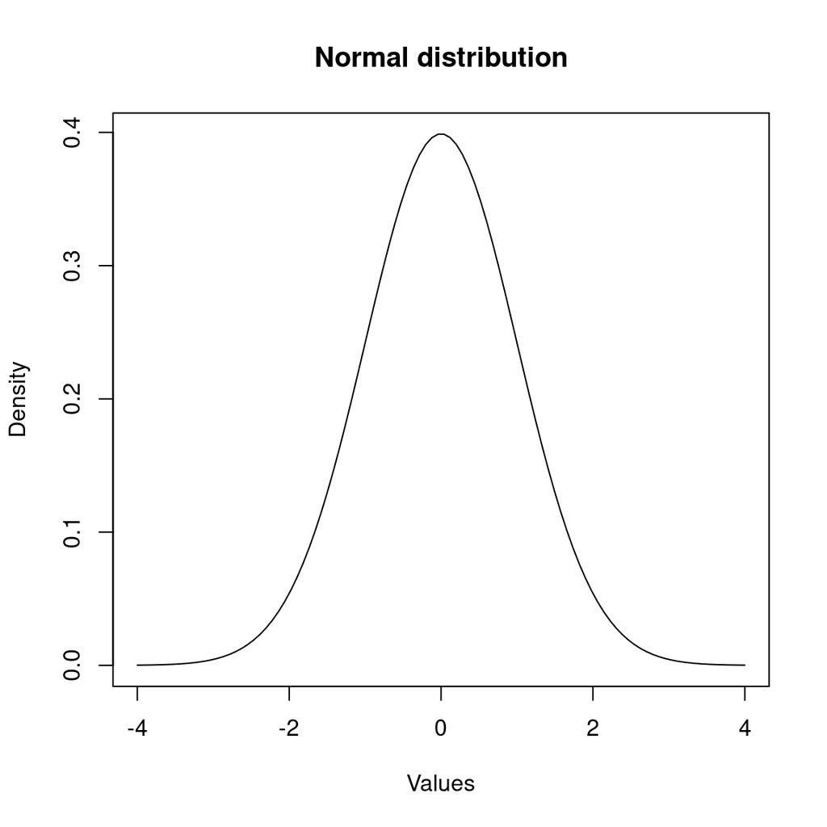

## Density histogram

[figure not shown]

```r
palmerpenguins::penguins %>%
  ggplot2::ggplot(
    aes(x = flipper_length_mm)
  ) +
  ggplot2::geom_histogram(
    aes(
      y =..density..
    )
  ) +
  ggplot2::stat_function(
    fun = dnorm,
    args = list(
      # mean and stddev
      # calculations
      # omitted here
      mean = ...,
      sd = ... ),
    colour = "black", size = 1)
```

## Q-Q plot

Values against the cumulative probability of a particular distribution (in this case, *normal* distribution)

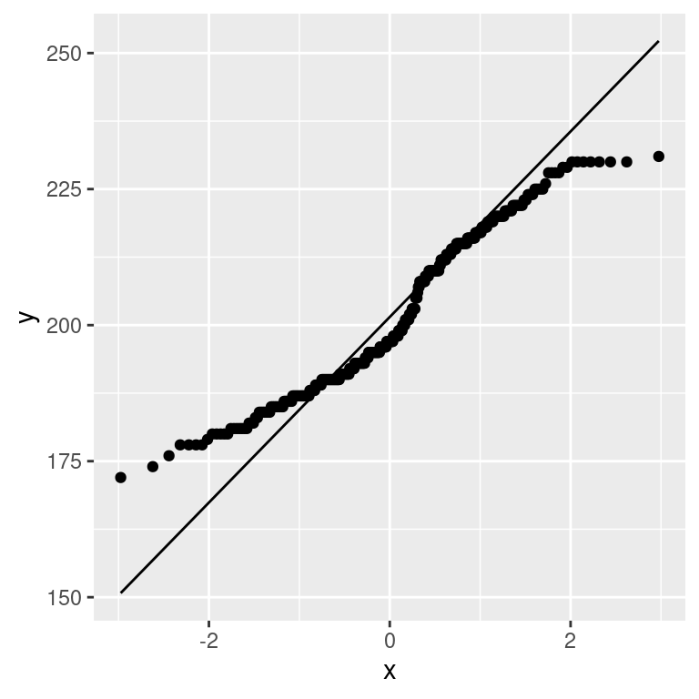

```r
palmerpenguins::penguins %>%
  ggplot2::ggplot(
    aes(
      sample =
        flipper_length_mm
    )
  ) +
  ggplot2::stat_qq() +
  ggplot2::stat_qq_line()
```

## Normality

**Shapiro–Wilk test** compares the distribution of a variable with a normal distribution having same mean and standard deviation

- If significant, the distribution is not normal
- `shapiro.test` function in `stats`
- or `normtest` values in `pastecs::stat.desc`

```r
palmerpenguins::penguins %>%
  dplyr::pull(flipper_length_mm) %>%
  stats::shapiro.test()
```

```
##
##  Shapiro-Wilk normality test
##
## data:  .
## W = 0.95155, p-value = 3.54e-09
```

## Significance

Most statistical tests are based on the idea of hypothesis testing

- a **null hypothesis** is set
- the data are fit into a statistical model
- the model is assessed with a **test statistic**
- the **significance** is the probability of obtaining that test statistic value by chance

The threshold to accept or reject an hypotheis is arbitrary and based on conventions (e.g., *p < .01* or *p < .05*)

**Example:** The null hypotheis of the Shapiro–Wilk test is that the sample is normally distributed and *p < .01* indicates that the probability of that being true is very low. So, the *flipper length* of penguins in the Palmer Station dataset **is not** normally distributed.

## Example

The *flipper length* of **Adelie** penguins **is normally distributed**

```r
palmerpenguins::penguins %>%
  filter(
    species == "Adelie"
  ) %>%
  dplyr::pull(
    flipper_length_mm
  ) %>%
  stats::shapiro.test()
```

```
##
##  Shapiro-Wilk normality test
##
## data:  .
## W = 0.99339, p-value = 0.72
```

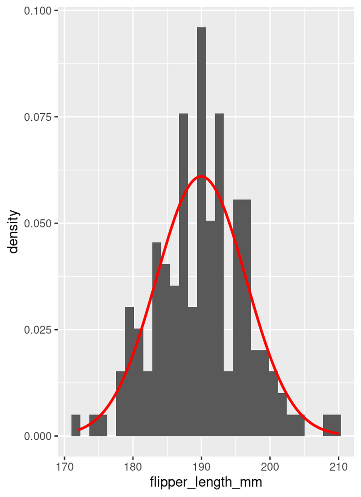

## Example

The *flipper length* of **Adelie** penguins **is normally distributed**

```r
palmerpenguins::penguins %>%
  filter(
    species == "Adelie"
  ) %>%
  dplyr::pull(
    flipper_length_mm
  ) %>%
  stats::shapiro.test()
```

```
##
##  Shapiro-Wilk normality test
##
## data:  .
## W = 0.99339, p-value = 0.72
```

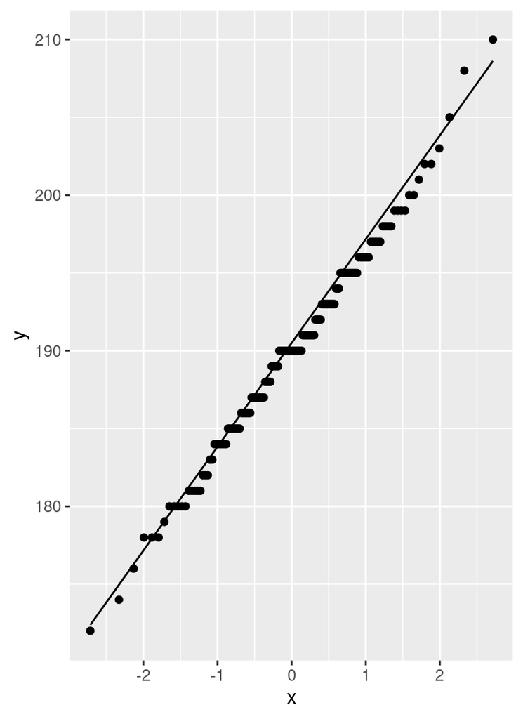

## Skewness and kurtosis

In a normal distribution, *skewness* and *kurtosis* should be **zero**

- `skewness`: **skewness** value indicates
  - positive: the distribution is skewed towards the left
  - negative: the distribution is skewed towards the right
- `kurtosis`: **kurtosis** value indicates
  - positive: heavy-tailed distribution
  - negative: flat distribution
- `skew.2SE` and `kurt.2SE`: skewness and kurtosis divided by 2 standard errors. Therefore
  - if `> 1` (or `< -1`) then the stat significant *(p < .05)*
  - if `> 1.29` (or `< -1.29`) then stat significant *(p < .01)*

## Example

*Flipper length* is not normally distributed

- skewed left (skewness positive, `skew.2SE > 1.29`)
- flat distribution (kurtosis negative, `kurt.2SE < -1.29`)

```r
palmerpenguins::penguins %>%
  dplyr::select(bill_length_mm, bill_depth_mm, flipper_length_mm) %>%
  pastecs::stat.desc(basic = FALSE, desc = FALSE, norm = TRUE)
```

|  | bill_length_mm | bill_depth_mm | flipper_length_mm |
| --- | --- | --- | --- |
| skewness | 0.0526530 | -0.1422086 | 0.3426554 |
| skew.2SE | 0.1996290 | -0.5391705 | 1.2991456 |
| kurtosis | -0.8931397 | -0.9233523 | -0.9991866 |
| kurt.2SE | -1.6979696 | -1.7554076 | -1.8995781 |
| normtest.W | 0.9748548 | 0.9725838 | 0.9515451 |
| normtest.p | 0.0000112 | 0.0000044 | 0.0000000 |

## Example

Values are instead not significant for **Adelie** penguins

- both `skew.2SE` and `kurt.2SE` between `-1` and `1`

```r
palmerpenguins::penguins %>%
  filter(species == "Adelie") %>%
  dplyr::select(bill_length_mm, bill_depth_mm, flipper_length_mm) %>%
  pastecs::stat.desc(basic = FALSE, desc = FALSE, norm = TRUE)
```

|  | bill_length_mm | bill_depth_mm | flipper_length_mm |
| --- | --- | --- | --- |
| skewness | 0.1584764 | 0.3148847 | 0.0856093 |
| skew.2SE | 0.4014211 | 0.7976035 | 0.2168485 |
| kurtosis | -0.2285951 | -0.1361153 | 0.2382734 |
| kurt.2SE | -0.2913388 | -0.1734755 | 0.3036734 |
| normtest.W | 0.9933618 | 0.9846683 | 0.9933916 |
| normtest.p | 0.7166005 | 0.0924897 | 0.7200466 |

## Homogeneity of variance

**Levene’s test** for equality of variance in different levels

- If significant, the variance is different in different levels

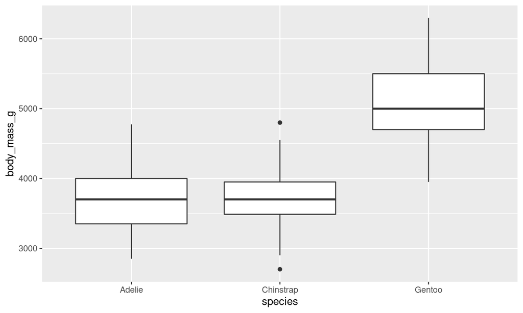

```
## Levene's Test for Homogeneity of Variance (center = median)
##        Df F value   Pr(>F)
## group   2  5.1203 0.006445 **
##       339
## ---
## Signif. codes:  0 '***' 0.001 '**' 0.01 '*' 0.05 '.' 0.1 ' ' 1
```

```r
library(car)
palmerpenguins::penguins %>%
  car::leveneTest(
    body_mass_g ~ species, data = .
  )
```

## Summary

Exploring assumptions

- Normality
- Skewness and kurtosis
- Homogeneity of variance

**Next**: Practical session

- Data visualisation
- Descriptive statistics
- Exploring assumptions